# EM for Mixtures of t-Distributions

Computational Statistics — Assignment 3, topic B

## Roadmap

1. **The model** and deriving the EM algorithm
2. **Version 1 → version 2**: a generalized EM that actually *is* one
3. **Testing**: how do I know it is correct?
4. **Alternatives**: augmented EM, exact EM, gradient ascent, BFGS
5. **Code structure**: one driver, many step functions, an S3 class
6. **Convergence criteria and benchmarking** (`bench::mark`, `bench::press`)
7. **Profiling** (`Rprof`/`profvis`) and optimization (R → Rcpp)
8. **Theory check**: Fisher information and convergence rates
9. **Robustness**: starting values, many data sets, outliers

Throughout: boxes like this one mark what I learned along the way.

# The model

## Two-component mixture of $t$-distributions

$$f(x \mid \theta) = p\, f(x \mid \mu_1, \sigma_1^2, \nu_1) + (1 - p)\, f(x \mid \mu_2, \sigma_2^2, \nu_2),
\qquad \theta = (p, \mu_1, \mu_2, \sigma_1, \sigma_2)$$

with $f(x \mid \mu, \sigma^2, \nu) = \frac{\Gamma((\nu+1)/2)}{\sqrt{\pi\nu\sigma^2}\,\Gamma(\nu/2)}\left(1 + \frac{(x-\mu)^2}{\nu\sigma^2}\right)^{-(\nu+1)/2}$ and $\nu_1, \nu_2$ fixed.

Simulated data as in the assignment:

```r
set.seed(42)
nu <- c(5, 10)
par_true <- c(p = 0.6, mu1 = 0, mu2 = 3,
              sigma1 = 1, sigma2 = 0.7)
x <- rtmix(400, par_true, nu)
par0 <- default_start(x)
round(par0, 3)
```

```
#> [1]  0.500 -0.495  2.904  0.963  0.963
```

`default_start()`: $p = 0.5$, quartiles for $\mu$, $\text{sd}(x)/2$ for $\sigma$.

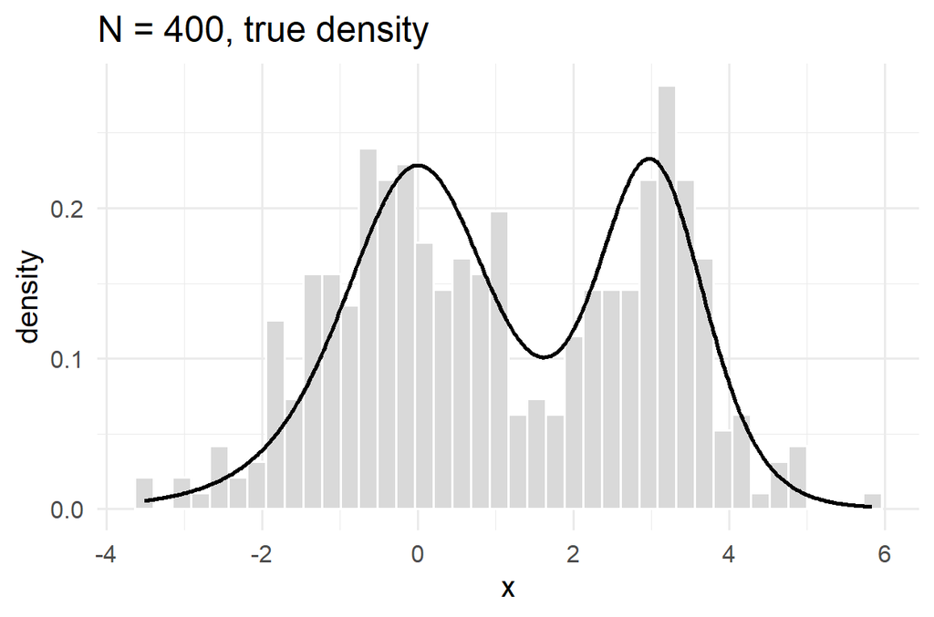

Figure 1

## Missing data: the component labels

**Idea:** if we knew which component each $x_i$ came from, estimation would be easy — just like the two coins in lecture 9.

Introduce the (unobserved) label $Z_i \in \{1, 2\}$:
$$P(Z_i = 1) = p, \qquad X_i \mid Z_i = j \sim t(\mu_j, \sigma_j^2, \nu_j).$$

Write $f_j(x) = f(x \mid \mu_j, \sigma_j^2, \nu_j)$. The joint density of one complete observation $(x_i, z_i)$ is
$$f(x_i, z_i \mid \theta) = \big(p\, f_1(x_i)\big)^{\mathbf{1}(z_i = 1)} \big((1 - p)\, f_2(x_i)\big)^{\mathbf{1}(z_i = 2)}.$$

**Check:** summing over $z_i \in \{1, 2\}$ gives $p f_1(x_i) + (1-p) f_2(x_i)$ — exactly the mixture density. So $(X, Z)$ is a valid complete-data model for our observed $X$.

**Complete-data log-likelihood** (what we could maximize if $Z$ were observed):
$$\ell_c(\theta) = \sum_{i=1}^N \mathbf{1}(Z_i = 1)\big(\log p + \log f_1(x_i)\big) + \mathbf{1}(Z_i = 2)\big(\log(1-p) + \log f_2(x_i)\big)$$

With $Z$ known: $p$ = fraction of labels equal to 1, and $(\mu_j, \sigma_j)$ = a $t$-fit to group $j$ alone. But $Z$ is missing.

## E-step: from $\ell_c$ to $Q$

$Q(\theta \mid \theta') = E_{\theta'}\big(\ell_c(\theta) \mid X = x\big)$ — average $\ell_c$ over what the labels could be, given the data and the current guess $\theta'$.

**Step 1 — linearity.** Given $x$, the terms $\log p + \log f_1(x_i)$ are just numbers, so the expectation only hits the indicators:
$$E_{\theta'}\big(\mathbf{1}(Z_i = 1) \mid X = x\big) = P_{\theta'}(Z_i = 1 \mid X_i = x_i) =: \gamma_i$$
(the observations are independent, so only $x_i$ matters for $Z_i$).

**Step 2 — Bayes’ formula.**
$$\gamma_i = \frac{P(Z_i = 1)\, f(x_i \mid Z_i = 1)}{f(x_i)} = \frac{p' f_1'(x_i)}{p' f_1'(x_i) + (1 - p') f_2'(x_i)}$$

**Result:**
$$Q(\theta \mid \theta') = \sum_{i=1}^N \gamma_i \big(\log p + \log f_1(x_i)\big) + (1 - \gamma_i)\big(\log(1-p) + \log f_2(x_i)\big)$$

The $\gamma_i$ are computed from the **old** $\theta'$ and are fixed numbers (“soft labels”); $\theta$ in the logs is the **new** parameter we optimize over.

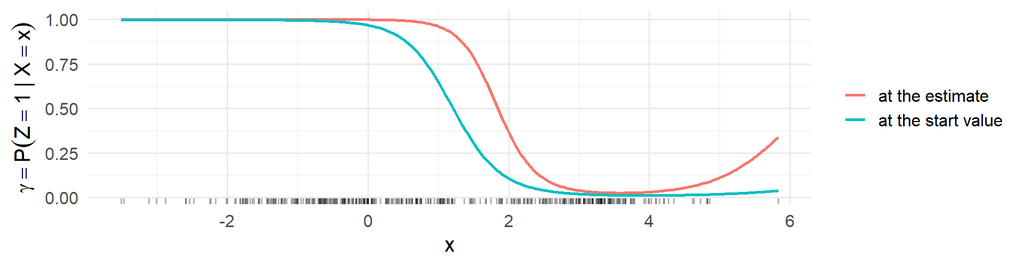

Figure 2

Far to the right $\gamma$ rises again: component 1 has heavier tails ($\nu_1 = 5$, larger $\sigma_1$), so an extreme point is better explained by component 1 than by component 2.

## M-step: maximize $Q$ — what can be solved?

$Q$ splits into three parts that can be maximized separately:
$$Q = \underbrace{\sum_i \gamma_i \log p + (1 - \gamma_i)\log(1-p)}_{\text{only } p}
+ \underbrace{\sum_i \gamma_i \log f_1(x_i)}_{\text{only } \mu_1, \sigma_1}
+ \underbrace{\sum_i (1 - \gamma_i) \log f_2(x_i)}_{\text{only } \mu_2, \sigma_2}$$

**$p$:** $\ \partial_p Q = \frac{\sum_i \gamma_i}{p} - \frac{N - \sum_i \gamma_i}{1 - p} = 0 \;\Rightarrow\; p = \frac{1}{N}\sum_i \gamma_i$ — closed form.

**$(\mu_1, \sigma_1)$:** a *weighted* $t$ log-likelihood. With $r = x - \mu_1$ and $\log f_1(x) = c(\nu_1) - \log \sigma_1 - \frac{\nu_1 + 1}{2}\log\big(1 + \frac{r^2}{\nu_1 \sigma_1^2}\big)$, the chain rule gives
$$\partial_{\mu_1} \log f_1(x) = \frac{\nu_1 + 1}{2}\cdot\frac{2r / (\nu_1\sigma_1^2)}{1 + r^2/(\nu_1\sigma_1^2)} = \frac{w\, r}{\sigma_1^2},
\qquad
\partial_{\sigma_1} \log f_1(x) = -\frac{1}{\sigma_1} + \frac{w\, r^2}{\sigma_1^3},
\qquad w = \frac{\nu_1 + 1}{\nu_1 + r^2/\sigma_1^2}.$$

Summing with weights $\gamma_i$ gives the gradient of $Q$:
$$\partial_{\mu_1} Q = \sum_i \gamma_i \frac{w_{i1} r_{i1}}{\sigma_1^2}, \qquad
\partial_{\sigma_1} Q = \sum_i \frac{\gamma_i}{\sigma_1}\left(\frac{w_{i1} r_{i1}^2}{\sigma_1^2} - 1\right) \qquad (\text{same for component 2 with } 1 - \gamma_i).$$

Setting $\partial_{\mu_1} Q = 0$ gives $\mu_1 = \frac{\sum_i \gamma_i w_{i1} x_i}{\sum_i \gamma_i w_{i1}}$ — it *looks* like a weighted mean, but $w_{i1}$ depends on $\mu_1$ and $\sigma_1$ themselves. It is a fixed-point equation, not a formula. (For a Gaussian mixture $w_{i1} \equiv 1$ and it *is* a formula.)

No closed-form M-step for $(\mu, \sigma)$. **Generalized EM:** we only need $Q(\theta_{n+1} \mid \theta_n) \ge Q(\theta_n \mid \theta_n)$, so: exact update of $p$ + one uphill (gradient) step for $(\mu_1, \mu_2, \sigma_1, \sigma_2)$.

## From formulas to code: the E-step

Numerical detail: for an outlier, $f_1(x_i)$ and $f_2(x_i)$ can both be tiny, and $\gamma_i$ is a ratio of two tiny numbers. So everything is computed on **log scale**:
$$a_i = \log p + \log f_1(x_i), \quad b_i = \log(1-p) + \log f_2(x_i), \quad
\gamma_i = \frac{e^{a_i}}{e^{a_i} + e^{b_i}} = \frac{1}{1 + e^{b_i - a_i}} = \texttt{plogis}(a_i - b_i)$$
and $\ell(\theta) = \sum_i \log(e^{a_i} + e^{b_i})$ with the log-sum-exp trick.

```r
ldt_ls <- function(x, mu, sigma, nu) {
  lgamma((nu + 1) / 2) - lgamma(nu / 2) - 0.5 * log(pi * nu) - log(sigma) -
    (nu + 1) / 2 * log1p((x - mu)^2 / (nu * sigma^2))
}

log_comp <- function(par, x, nu) {
  cbind(
    log(par[1]) + ldt_ls(x, par[2], par[4], nu[1]),
    log1p(-par[1]) + ldt_ls(x, par[3], par[5], nu[2])
  )
}

e_step <- function(par, x, nu) {
  lc <- log_comp(par, x, nu)
  plogis(lc[, 1] - lc[, 2])
}

loglik <- function(par, x, nu) {
  if (!valid_par(par)) {
    return(-Inf)
  }
  lc <- log_comp(par, x, nu)
  m <- pmax(lc[, 1], lc[, 2])
  sum(m + log(exp(lc[, 1] - m) + exp(lc[, 2] - m)))
}
```

## From formulas to code: $Q$ and its gradient

| Math | Code |
| --- | --- |
| $\gamma_i$ (from old $\theta'$) | `gam = e_step(par0, x, nu)` — can be passed in, so the E-step is done *once* per iteration even if $Q$ is evaluated many times in the line search |
| $\log p + \log f_1(x_i)$ | `log(par[1]) + ldt_ls(x, par[2], par[4], nu[1])` |
| $r_{i1}$, $w_{i1}$ | `r1 <- x - par[2]`, `w1 <- (nu[1] + 1) / (nu[1] + r1^2 / s1^2)` |
| $\partial_{\mu_1} Q = \sum_i \gamma_i w_{i1} r_{i1} / \sigma_1^2$ | `sum(gam * w1 * r1) / s1^2` |

```r
Q <- function(par, par0, x, nu, gam = e_step(par0, x, nu)) {
  if (!valid_par(par)) {
    return(-Inf)
  }
  sum(
    gam * (log(par[1]) + ldt_ls(x, par[2], par[4], nu[1])) +
      (1 - gam) * (log1p(-par[1]) + ldt_ls(x, par[3], par[5], nu[2]))
  )
}

grad_Q <- function(par, par0, x, nu, gam = e_step(par0, x, nu)) {
  p <- par[1]
  s1 <- par[4]
  s2 <- par[5]
  r1 <- x - par[2]
  r2 <- x - par[3]
  w1 <- (nu[1] + 1) / (nu[1] + r1^2 / s1^2)
  w2 <- (nu[2] + 1) / (nu[2] + r2^2 / s2^2)
  c(
    sum(gam) / p - sum(1 - gam) / (1 - p),
    sum(gam * w1 * r1) / s1^2,
    sum((1 - gam) * w2 * r2) / s2^2,
    sum(gam * (w1 * r1^2 / s1^2 - 1)) / s1,
    sum((1 - gam) * (w2 * r2^2 / s2^2 - 1)) / s2
  )
}
```

## Checking the derivation numerically

Before building algorithms on top, check each formula against something independent:

```r
par_test <- c(0.4, -0.5, 2.5, 1.3, 0.9)

# E-step on log scale vs. the textbook formula with dt()
f1 <- par0[1] * dt((x - par0[2]) / par0[4], nu[1]) / par0[4]
f2 <- (1 - par0[1]) * dt((x - par0[3]) / par0[5], nu[2]) / par0[5]
all.equal(e_step(par0, x, nu), f1 / (f1 + f2))
```

```
#> [1] TRUE
```

```r
# analytic gradient of Q vs. numerical differentiation
g <- rbind(analytic  = grad_Q(par_test, par0, x, nu),
           numerical = numDeriv::grad(function(p) Q(p, par0, x, nu), par_test))
colnames(g) <- par_names
g
```

```
#>               p    mu1   mu2 sigma1 sigma2
#> analytic  241.9 12.047 68.67 -66.19 28.275
#> numerical 241.9 12.047 68.67 -66.19 28.275
```

```r
# Fisher's identity: grad_Q(theta | theta) is the gradient of the log-likelihood
g <- rbind(fisher_identity = grad_loglik(par_test, x, nu),
           numerical       = numDeriv::grad(function(p) loglik(p, x, nu), par_test))
colnames(g) <- par_names
g
```

```
#>                      p   mu1  mu2  sigma1 sigma2
#> fisher_identity 187.77 4.807 38.4 -58.139 66.339
#> numerical       187.77 4.807 38.4 -58.139 66.339
```

Deriving by hand and checking against `numDeriv` catches sign and chain-rule errors before they turn into a mysteriously slow or wrong algorithm.

# Version 1 → version 2

## GEM, version 1: one gradient step with a fixed step size

```r
create_gem_step_v1 <- function(x, nu, gamma = 1e-3) {
  force(x)
  force(nu)
  function(par) {
    gam <- e_step(par, x, nu)
    par[1] <- mean(gam)
    g <- grad_Q(par, par, x, nu, gam)
    g[1] <- 0
    par + gamma * g
  }
}
```

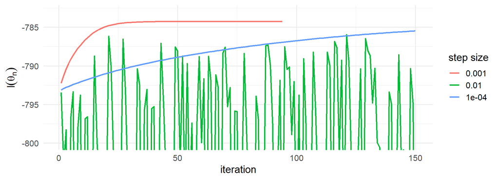

Figure 3

With step size 0.01 the log-likelihood **decreases** in many iterations — the step does not increase $Q$, so it is not a GEM algorithm. With $10^{-4}$ it crawls. The right step size depends on $N$ and $\sigma^2$ (the gradient scales like $N/\sigma^2$).

## GEM, version 2: backtracking line search on $Q$

A GEM step only has to satisfy $Q(\theta_{n+1} \mid \theta_n) \ge Q(\theta_n \mid \theta_n)$. Enforce it with an Armijo condition:

```r
create_gem_step <- function(x, nu, gamma0 = 1, d = 0.5, c = 0.1, warm = FALSE) {
  force(x)
  force(nu)
  gamma_last <- gamma0

  function(par) {
    gam <- e_step(par, x, nu) # E-step
    par[1] <- mean(gam) # exact M-step for p
    Q_val <- Q(par, par, x, nu, gam)
    g <- grad_Q(par, par, x, nu, gam)
    g[1] <- 0 # p is already optimal
    gamma <- if (warm) gamma_last / d else gamma0

    repeat {
      par_new <- par + gamma * g
      if (Q(par_new, par, x, nu, gam) >= Q_val + c * gamma * sum(g^2)) {
        break
      }
      gamma <- d * gamma
      if (gamma < 1e-14) {
        return(par) # no ascent possible: we are at a stationary point
      }
    }
    gamma_last <<- gamma
    par_new
  }
}
```

A GEM needs a *guaranteed* increase of $Q$ — that is exactly what backtracking gives. Then the ascent property $\ell(\theta_{n+1}) \ge \ell(\theta_n)$ follows from the EM theory.

## Running it

```r
theta_gem <- em(par0, create_gem_step(x, nu))
theta_gem
```

```
#>        p      mu1      mu2   sigma1   sigma2
#>  0.62318 -0.19571  3.10559  1.02543  0.65750
#> attr(,"iter")
#> [1] 31
```

```r
loglik(theta_gem, x, nu)
```

```
#> [1] -784.25
```

`em()` is the driver from the lecture (same stopping rule: $\|\theta_n - \theta_{n-1}\|^2 \le \varepsilon(\|\theta_n\|^2 + \varepsilon)$), extended so the criterion is a function argument. More on that later.

# Testing

## How can I test that the implementation is correct?

| What | How |
| --- | --- |
| Building blocks | `ldt_ls()` against `dt()`; mixture density integrates to 1 |
| Analytic gradient of $Q$ | against `numDeriv::grad()` |
| Fisher’s identity $\nabla \ell(\theta) = \nabla_\theta Q(\theta \mid \theta)$ | against `numDeriv::grad(loglik)` |
| Different implementations of the same step | naive, readable, optimized R and Rcpp give the same result |
| GEM property | $Q(\theta_{n+1}\mid\theta_n) \ge Q(\theta_n\mid\theta_n)$ and $\ell(\theta_n)$ non-decreasing |
| Convergence | all 7 methods reach the same point; $\nabla\ell(\hat\theta) \approx 0$; $\hat\theta$ is a fixed point of the EM map |
| Statistical sanity | large $N$ recovers the true parameters |
| Fisher information | three different methods agree |

```r
test_that("gradient of Q matches numerical differentiation", {
  num <- numDeriv::grad(function(p) Q(p, par0, x, nu), par_rand)
  expect_equal(grad_Q(par_rand, par0, x, nu), num, tolerance = 1e-6)
})
```

## Running the test suite

```r
test_res <- testthat::test_file("tests/test-tmix.R", reporter = "silent")
as.data.frame(test_res)[, c("test", "nb", "failed", "error")]
```

```
#>                                                                    test nb failed error
#> 1    t log-density matches dt() and the mixture density integrates to 1  2      0 FALSE
#> 2                       gradient of Q matches numerical differentiation  1      0 FALSE
#> 3                     Fisher's identity: grad_Q(par | par) is the score  1      0 FALSE
#> 4              the three implementations of the augmented EM step agree  3      0 FALSE
#> 5 GEM steps increase Q, and all EM variants increase the log-likelihood 23      0 FALSE
#> 6                     all methods converge to the same stationary point 10      0 FALSE
#> 7                   estimates are close to the truth for a large sample  1      0 FALSE
#> 8              the three ways of computing the Fisher information agree  2      0 FALSE
```

While writing the tests I passed the data to `numDeriv::jacobian(f, par, x = x)` — but `x` is also the name of `jacobian()`’s own argument, so it silently differentiated with respect to the *data*. Now data are passed via closures.

# Alternative solutions

## Idea: add *more* missing data

A $t$-variable is a scale mixture of normals: with $W \mid Z = j \sim \Gamma(\nu_j/2, \text{rate} = \nu_j/2)$ and
$$X \mid W = w, Z = j \sim \mathcal{N}(\mu_j, \sigma_j^2 / w)$$
we get $X \mid Z = j \sim t(\mu_j, \sigma_j^2, \nu_j)$. Complete data $(X, Z, W)$:

- $W \mid X = x, Z = j \sim \Gamma\big(\tfrac{\nu_j + 1}{2}, \tfrac{\nu_j + (x-\mu_j)^2/\sigma_j^2}{2}\big)$, so $E(W \mid x, Z = j) = \frac{\nu_j+1}{\nu_j + (x-\mu_j)^2/\sigma_j^2} = w_{ij}$
- $Q_{\text{aug}}$ is a *weighted Gaussian* log-likelihood → **closed-form M-step**:

$$p = \tfrac1N \textstyle\sum_i \gamma_i, \qquad
\mu_1 = \frac{\sum_i \gamma_i w_{i1} x_i}{\sum_i \gamma_i w_{i1}}, \qquad
\sigma_1^2 = \frac{\sum_i \gamma_i w_{i1} (x_i - \mu_1)^2}{\sum_i \gamma_i}$$

```r
m_step_aug <- function(e, x) {
  a1 <- e$gam * e$w1
  a2 <- (1 - e$gam) * e$w2
  mu1 <- sum(a1 * x) / sum(a1)
  mu2 <- sum(a2 * x) / sum(a2)
  N1 <- sum(e$gam)
  N2 <- length(x) - N1
  c(
    N1 / length(x),
    mu1,
    mu2,
    sqrt(sum(a1 * (x - mu1)^2) / N1),
    sqrt(sum(a2 * (x - mu2)^2) / N2)
  )
}

create_em_aug_step <- function(x, nu) {
  force(x)
  force(nu)
  function(par) m_step_aug(e_step_aug(par, x, nu), x)
}
```

## Insight: the augmented EM is a *scaled* gradient step on $Q$

Using $\partial_{\mu_1} Q = \sum_i \gamma_i w_{i1}(x_i - \mu_1)/\sigma_1^2$:

$$\mu_1^{\text{new}} = \frac{\sum_i \gamma_i w_{i1} x_i}{\sum_i \gamma_i w_{i1}}
= \mu_1 + \frac{\sigma_1^2}{\sum_i \gamma_i w_{i1}}\, \partial_{\mu_1} Q(\theta \mid \theta)$$

- The augmented EM is **also a GEM for the original $Q$**: it takes a gradient step with an automatically chosen step size $\sigma^2 / \sum_i \gamma_i w_{i1}$, which is guaranteed to increase $Q$ (it is an MM-step).
- Compare with version 1: the step size $\approx \sigma^2 / N_1$ explains why a fixed step size could not work.

Two different sets of missing data give two different EM algorithms for the same likelihood. Choosing the missing data cleverly gives a closed-form M-step.

## More alternatives

**Exact EM** (only $Z$ missing): solve the M-step numerically — a weighted $t$-MLE per component with `optim(method = "BFGS")` in $(\mu, \log\sigma)$.

**Direct optimization of $\ell(\theta)$** — the gradient comes for free from Fisher’s identity: `grad_loglik <- function(par, x, nu) grad_Q(par, par, x, nu)`

- Gradient ascent with backtracking on $\ell$ (`create_gd_step()`)
- BFGS via `optim()` in $\eta = (\operatorname{logit} p, \mu_1, \mu_2, \log\sigma_1, \log\sigma_2)$ (`fit_bfgs()`)

The GEM gradient step at $\theta_n$ uses $\nabla_\theta Q(\theta_n \mid \theta_n) = \nabla \ell(\theta_n)$ — the *same direction* as gradient ascent on $\ell$. The differences are the exact $p$-update and the line search on $Q$ instead of $\ell$.

## All seven methods agree

```r
fits <- lapply(tmix_methods, function(m) tmix(x, nu, par0, method = m))
data.frame(
  method = tmix_methods,
  iterations = sapply(fits, `[[`, "iter"),
  loglik = sapply(fits, `[[`, "loglik"),
  t(sapply(fits, coef))
)
```

```
#>        method iterations  loglik       p      mu1    mu2 sigma1  sigma2
#> 1      em_aug         42 -784.25 0.62317 -0.19574 3.1056 1.0254 0.65754
#> 2 em_aug_fast         42 -784.25 0.62317 -0.19574 3.1056 1.0254 0.65754
#> 3  em_aug_cpp         42 -784.25 0.62317 -0.19574 3.1056 1.0254 0.65754
#> 4         gem         31 -784.25 0.62318 -0.19571 3.1056 1.0254 0.65750
#> 5    em_exact         33 -784.25 0.62317 -0.19572 3.1056 1.0254 0.65752
#> 6          gd         66 -784.25 0.62315 -0.19582 3.1055 1.0254 0.65756
#> 7        bfgs         12 -784.25 0.62319 -0.19566 3.1056 1.0255 0.65748
```

(`em_aug_fast` and `em_aug_cpp` are optimized versions of `em_aug` — see profiling. BFGS “iterations” are gradient evaluations.)

# Code structure

## One driver, many step functions

```r
em <- function(par, em_step, eps = 1e-10, maxit = 5000, cb = NULL,
               conv = par_conv(eps)) {
  for (i in seq_len(maxit)) {
    par0 <- par
    par <- em_step(par)

    if (!is.null(cb)) {
      cb()
    }

    if (conv(par, par0)) {
      break
    }
  }
  par <- setNames(as.vector(par), par_names)
  attr(par, "iter") <- i
  par
}

par_conv <- function(eps = 1e-10) {
  force(eps)
  function(par, par0) sum((par - par0)^2) <= eps * (sum(par^2) + eps)
}
```

- Every algorithm (EM, GEM, gradient ascent) is a map $\theta \mapsto \theta_{\text{new}}$ created by a **function factory** (`create_*_step(x, nu)`), which stores data and state (e.g. the last step size) in its closure.
- The convergence criterion is a **function argument** → *exactly* the same criterion can be used for all algorithms.
- Callback `cb` for tracing (own `make_tracer()`, like `CSwR::tracer()`, which subtracts its own overhead from the time).

## An S3 class on top

```r
fit <- tmix(x, nu, method = "em_aug")
fit
```

```
#> Two-component t-mixture, nu = (5, 10)
#> Method: em_aug | iterations: 42 | loglik: -784.25152
#>
#>                p      mu1     mu2  sigma1 sigma2
#> estimate 0.62317 -0.19574 3.10555 1.02539 0.6575
#> se       0.03124  0.09366 0.07375 0.07676 0.0642
```

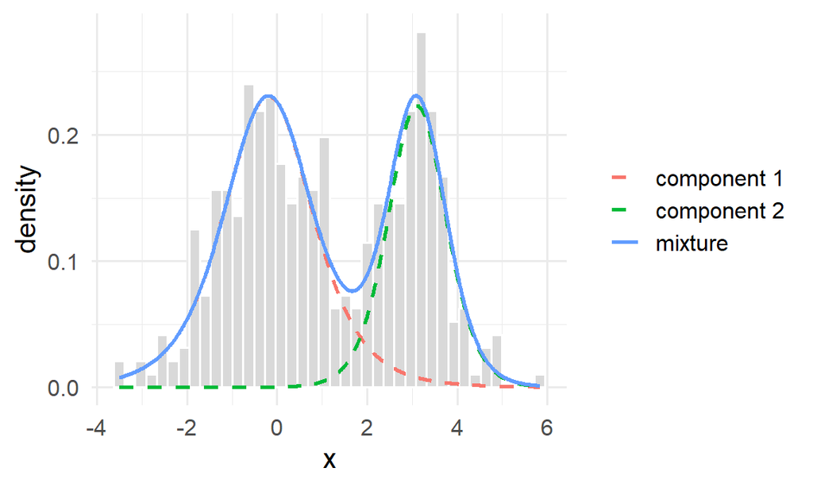

```r
plot(fit)
```

Methods: `print()`, `plot()`, `coef()`, `logLik()` (so `AIC()` works), `vcov()` (Fisher information) and `predict()` (responsibilities).

Files:

- `R/tmix-model.R` — density, $\ell$, E-step, $Q$, $\nabla Q$
- `R/em-algorithms.R` — driver + EM/GEM steps
- `R/direct-methods.R` — gradient ascent, BFGS
- `R/fisher.R`, `R/tracer.R`, `R/tmix-class.R`
- `src/em_aug_step.cpp`, `tests/test-tmix.R`

# Convergence

## Tracing the algorithms

```r
par_hat <- em(par0, create_em_aug_step(x, nu), conv = par_conv(1e-24), maxit = 2000)
ll_hat <- loglik(par_hat, x, nu)
runs <- list(
  em_aug   = function(cb) em(par0, create_em_aug_step(x, nu), cb = cb, conv = par_conv(1e-24), maxit = 150),
  em_exact = function(cb) em(par0, create_em_exact_step(x, nu), cb = cb, conv = par_conv(1e-24), maxit = 150),
  gem      = function(cb) em(par0, create_gem_step(x, nu), cb = cb, conv = par_conv(1e-24), maxit = 150),
  gd       = function(cb) em(par0, create_gd_step(x, nu), cb = cb, conv = par_conv(1e-24), maxit = 150)
)
traces <- do.call(rbind, Map(trace_run, runs, label = names(runs), MoreArgs = list(x = x, nu = nu)))
traces$par_dist <- sqrt(rowSums(sweep(as.matrix(traces[, 3:7]), 2, par_hat)^2))
```

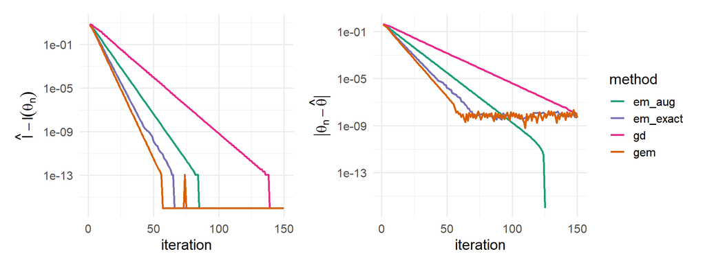

Figure 4

All four increase $\ell$ monotonically and converge **linearly** (straight lines on log scale).

## The stopping criterion is not neutral

```r
crit <- expand.grid(eps = 10^-c(6, 8, 10, 12), method = c("em_aug", "gem"), stringsAsFactors = FALSE)
crit_res <- t(mapply(function(eps, method) {
  step <- if (method == "em_aug") create_em_aug_step(x, nu) else create_gem_step(x, nu)
  th <- em(par0, step, eps = eps)
  c(iter = attr(th, "iter"), gap = ll_hat - loglik(th, x, nu),
    grad_norm = sqrt(sum(grad_loglik(th, x, nu)^2)) / length(x))
}, crit$eps, crit$method))
cbind(crit, signif(crit_res, 3))
```

```
#>     eps method iter      gap grad_norm
#> 1 1e-06 em_aug   19 7.71e-03  3.33e-03
#> 2 1e-08 em_aug   31 6.99e-05  3.16e-04
#> 3 1e-10 em_aug   42 9.46e-07  3.68e-05
#> 4 1e-12 em_aug   54 8.67e-09  3.52e-06
#> 5 1e-06    gem   15 2.72e-03  2.23e-03
#> 6 1e-08    gem   23 2.49e-05  2.13e-04
#> 7 1e-10    gem   31 2.31e-07  2.05e-05
#> 8 1e-12    gem   38 3.84e-09  2.64e-06
```

- Near $\hat\theta$: $\theta_n - \hat\theta \approx \rho\,(\theta_{n-1} - \hat\theta)$, so $\|\theta_n - \hat\theta\| \approx \frac{\rho}{1-\rho}\|\theta_n - \theta_{n-1}\|$.
- A slowly converging algorithm (large $\rho$) takes small steps and **stops further from the optimum** for the same $\varepsilon$.

Same $\varepsilon$ ≠ same accuracy. For benchmarks I either stop on the **gradient** $\|\nabla\ell(\theta_n)\|/N \le \text{tol}$ (cheap thanks to Fisher’s identity: `grad_conv()`) or compare convergence as a function of **real time**.

# Benchmarking

## `bench::mark` with the same (gradient) criterion

```r
conv <- grad_conv(x, nu, tol = 1e-7)
same_estimate <- function(a, b) isTRUE(all.equal(as.vector(a), as.vector(b), tolerance = 1e-5))
bm <- bench::mark(
  em_aug   = em(par0, create_em_aug_step(x, nu), conv = conv),
  em_exact = em(par0, create_em_exact_step(x, nu), conv = conv),
  gem      = em(par0, create_gem_step(x, nu, warm = TRUE), conv = conv),
  gem_cold = em(par0, create_gem_step(x, nu), conv = conv),
  gd       = em(par0, create_gd_step(x, nu), conv = conv),
  bfgs     = fit_bfgs(par0, x, nu, reltol = 1e-12),
  check = same_estimate, min_iterations = 20 # all methods must give the same estimate
)
res <- bm$result
data.frame(method = as.character(bm$expression), median = format(bm$median), mem = format(bm$mem_alloc),
  iter = sapply(res, attr, "iter"),
  gap = signif(sapply(res, function(p) ll_hat - loglik(p, x, nu)), 2))
```

```
#>     method  median     mem iter     gap
#> 1   em_aug 10.32ms  7.69MB   73 5.1e-12
#> 2 em_exact 43.05ms 17.05MB   59 2.6e-12
#> 3      gem 19.29ms  6.99MB   50 3.4e-12
#> 4 gem_cold 35.54ms  9.91MB   50 3.4e-12
#> 5       gd 61.64ms 26.13MB  122 3.6e-12
#> 6     bfgs  3.89ms  1.73MB   12 6.1e-11
```

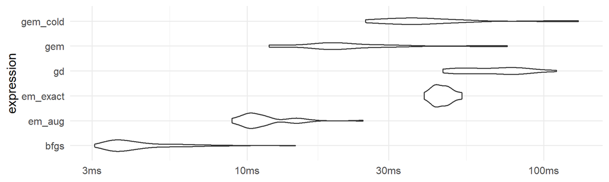

Figure 5

## Convergence as a function of real time

A larger data set ($N = 5000$) so that times are not dominated by overhead:

```r
set.seed(7)
x_big <- rtmix(5000, par_true, nu)
p0_big <- default_start(x_big)
ll_hat_big <- loglik(em(p0_big, create_em_aug_step(x_big, nu), conv = par_conv(1e-24), maxit = 3000), x_big, nu)
runs_big <- list(
  em_aug   = function(cb) em(p0_big, create_em_aug_step(x_big, nu), cb = cb, conv = par_conv(1e-24), maxit = 200),
  em_exact = function(cb) em(p0_big, create_em_exact_step(x_big, nu), cb = cb, conv = par_conv(1e-24), maxit = 60),
  gem      = function(cb) em(p0_big, create_gem_step(x_big, nu, warm = TRUE), cb = cb, conv = par_conv(1e-24), maxit = 200),
  gem_cold = function(cb) em(p0_big, create_gem_step(x_big, nu), cb = cb, conv = par_conv(1e-24), maxit = 200),
  gd       = function(cb) em(p0_big, create_gd_step(x_big, nu), cb = cb, conv = par_conv(1e-24), maxit = 300),
  bfgs     = function(cb) fit_bfgs(p0_big, x_big, nu, reltol = 1e-16, cb = cb)
)
time_traces <- do.call(rbind, Map(trace_run, runs_big, label = names(runs_big),
                                  MoreArgs = list(x = x_big, nu = nu)))
# BFGS is traced in every function evaluation (also in line searches): use the best value so far
time_traces <- do.call(rbind, lapply(split(time_traces, time_traces$method),
  function(d) transform(d, gap = pmax(ll_hat_big - cummax(loglik), 1e-12))))
```

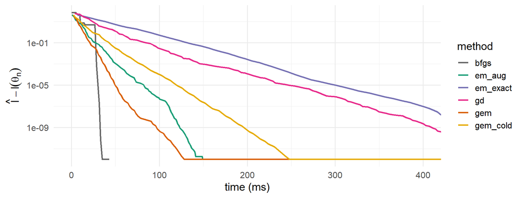

Figure 6

# Profiling

## Profiling the GEM (version 2)

```r
prof_file <- tempfile()
Rprof(prof_file, interval = 0.005)
for (i in 1:15) em(p0_big, create_gem_step(x_big, nu))
Rprof(NULL)
prof <- summaryRprof(prof_file)$by.total
prof[rownames(prof) %in% dQuote(c("em", "em_step", "Q", "ldt_ls", "grad_Q", "e_step", "plogis"), FALSE), ]
```

```
#>           total.time total.pct self.time self.pct
#> "em_step"      0.715     99.31     0.015     2.08
#> "em"           0.715     99.31     0.000     0.00
#> "Q"            0.545     75.69     0.035     4.86
#> "ldt_ls"       0.525     72.92     0.525    72.92
#> "e_step"       0.125     17.36     0.000     0.00
#> "plogis"       0.090     12.50     0.090    12.50
#> "grad_Q"       0.025      3.47     0.025     3.47
```

`profvis::profvis(em(p0_big, create_gem_step(x_big, nu)))` gives the same picture interactively (see `R/profiling-demo.R`).

Almost all time is spent in `Q()` → `ldt_ls()` **inside the line search**: backtracking starts from $\gamma_0 = 1$ in every iteration and needs ~10 halvings before $\gamma \approx \sigma^2/N$.

## Fix: warm-start the line search

Start from the last accepted step size divided by $d$ (i.e. try a slightly *larger* step first): `warm = TRUE`.

```r
bm_warm <- bench::mark(
  cold = em(p0_big, create_gem_step(x_big, nu, warm = FALSE), conv = grad_conv(x_big, nu, 1e-7)),
  warm = em(p0_big, create_gem_step(x_big, nu, warm = TRUE), conv = grad_conv(x_big, nu, 1e-7)),
  check = same_estimate, min_iterations = 5
)
data.frame(expression = as.character(bm_warm$expression), median = format(bm_warm$median),
           mem_alloc = format(bm_warm$mem_alloc), iter = sapply(bm_warm$result, attr, "iter"))
```

```
#>   expression median mem_alloc iter
#> 1       cold  246ms     139MB   51
#> 2       warm  121ms      88MB   51
```

Profiling pointed to a single line of code. Keeping *state* (the step size) in the closure of the step function halved the run time.

## Profiling the augmented EM

```r
Rprof(prof_file, interval = 0.005)
for (i in 1:15) em(p0_big, create_em_aug_step(x_big, nu), maxit = 100)
Rprof(NULL)
head(summaryRprof(prof_file)$by.self, 6)
```

```
#>              self.time self.pct total.time total.pct
#> "plogis"         0.065    41.94      0.065     41.94
#> "ldt_ls"         0.045    29.03      0.045     29.03
#> "sum"            0.015     9.68      0.015      9.68
#> "m_step_aug"     0.010     6.45      0.150     96.77
#> "e_step_aug"     0.010     6.45      0.120     77.42
#> "c"              0.005     3.23      0.005      3.23
```

Hot spots: `plogis()`, `ldt_ls()` (recomputes `lgamma()` constants every time), `cbind()` in `log_comp()`, and the squared residuals are computed twice (in `e_step()` and for $w_{ij}$).

## My first “optimization” made things slower

My first idea was to avoid `exp(log1p(.))` by computing $(1 + d/\nu)^{-(\nu+1)/2}$ directly. That version was *slower*. Measuring the pieces explains why:

```r
r <- rnorm(5000)
bench::mark(
  pow_integer    = (1 + r^2 / 5)^-3,      # nu = 5:  exponent -3
  pow_fractional = (1 + r^2 / 10)^-5.5,   # nu = 10: exponent -5.5
  exp_log1p      = exp(-5.5 * log1p(r^2 / 10)),
  plogis         = plogis(r),
  one_over       = 1 / (1 + exp(-r)),
  dt             = dt(r, 10),
  check = FALSE
)[, c("expression", "median", "itr/sec")]
```

```
#> # A tibble: 6 × 3
#>   expression       median `itr/sec`
#>   <bch:expr>     <bch:tm>     <dbl>
#> 1 pow_integer       210µs     4676.
#> 2 pow_fractional    502µs     1966.
#> 3 exp_log1p         355µs     2701.
#> 4 plogis            270µs     3611.
#> 5 one_over          205µs     4714.
#> 6 dt                834µs     1047.
```

`^` is only fast for *integer* exponents (R special-cases them); with $\nu_2 = 10$ the exponent is $-5.5$ and `pow()` is slower than `exp(log1p())`. `dt()` is slow, and `plogis()` is slower than `1/(1 + exp(-x))`. Measure, don’t guess.

## Optimized R and Rcpp

```r
create_em_aug_step_fast <- function(x, nu) {
  force(x)
  N <- length(x)
  lk <- lgamma((nu + 1) / 2) - lgamma(nu / 2) - 0.5 * log(pi * nu)
  h <- (nu + 1) / 2
  nu1 <- nu[1]
  nu2 <- nu[2]

  function(par) {
    r1 <- x - par[2]
    r2 <- x - par[3]
    d1 <- r1 * r1 / (par[4] * par[4])
    d2 <- r2 * r2 / (par[5] * par[5])
    # log(weighted f2) - log(weighted f1)
    const <- log1p(-par[1]) + lk[2] - log(par[5]) - log(par[1]) - lk[1] + log(par[4])
    gam <- 1 / (1 + exp(const - h[2] * log1p(d2 / nu2) + h[1] * log1p(d1 / nu1)))
    a1 <- gam * (nu1 + 1) / (nu1 + d1)
    a2 <- (1 - gam) * (nu2 + 1) / (nu2 + d2)
    mu1 <- sum(a1 * x) / sum(a1)
    mu2 <- sum(a2 * x) / sum(a2)
    N1 <- sum(gam)
    c(
      N1 / N, mu1, mu2,
      sqrt(sum(a1 * (x - mu1)^2) / N1),
      sqrt(sum(a2 * (x - mu2)^2) / (N - N1))
    )
  }
}
```

[output not shown]

The C++ version does E- and M-step in two passes over the data, without allocating any R vectors.

## `bench::press`: cost per EM step as a function of $N$

```r
press_res <- bench::press(N = c(500, 2000, 8000, 32000), {
  xN <- rtmix(N, par_true, nu)
  pN <- default_start(xN)
  s_v1 <- create_em_aug_step_v1(xN, nu)
  s_readable <- create_em_aug_step(xN, nu)
  s_fast <- create_em_aug_step_fast(xN, nu)
  bench::mark(v1 = s_v1(pN), readable = s_readable(pN), fast = s_fast(pN),
              cpp = em_aug_step_cpp(xN, pN, nu), check = TRUE) # check = TRUE: same result
})
```

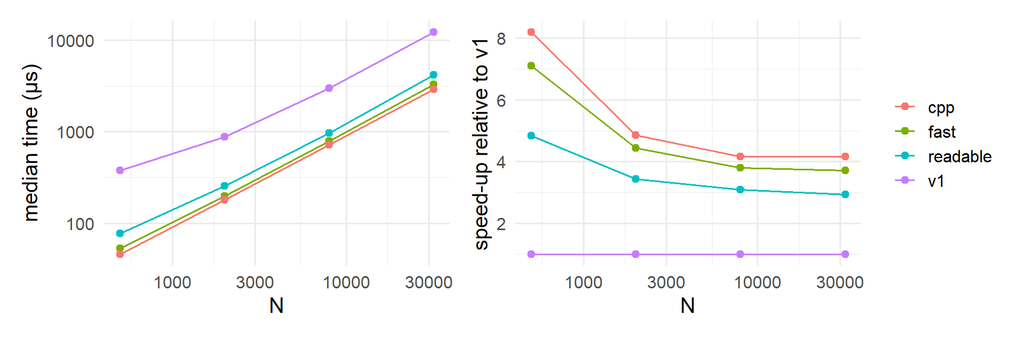

Figure 7

The biggest gain came from dropping `dt()` and the data frame (v1 → readable). Rcpp only gives a modest extra factor: vectorized R already runs in C, and the time is dominated by `log1p()` and `exp()`, which cost the same in C++. Rcpp’s real win here is **zero memory allocation**.

# Theory check

## Fisher information — three ways (lecture 10)

```r
i_score <- fisher_score(par_hat, x, nu)          # 1. differentiate the score (Fisher's identity)
louis   <- fisher_louis(par_hat, x, nu)          # 2. i_X = i_Y - i_{Y|X}, complete data (X, Z)
em_map  <- fisher_em_map(par_hat, x, nu)         # 3. i_X = (I - DPhi^T) i_Y, augmented EM map
c(louis = max(abs(louis$iX - i_score)), em_map = max(abs(em_map$iX - i_score)))
```

```
#>      louis     em_map
#> 6.8496e-09 2.7794e-08
```

```r
rbind(estimate = par_hat, se = sqrt(diag(solve(i_score))))
```

```
#>                 p       mu1     mu2   sigma1   sigma2
#> estimate 0.623195 -0.195658 3.10562 1.025471 0.657477
#> se       0.031246  0.093665 0.07374 0.076773 0.064195
```

The augmented EM map uses *other* complete data $(X, Z, W)$, so its $i_Y$ and $D\Phi$ differ from method 2 — but $i_X$ is the same, as it must be.

## Convergence rates: theory vs practice

Rate of the EM algorithm $= \rho(D\Phi(\hat\theta)) = \rho(i_{Y\mid X}\, i_Y^{-1})$ = “fraction of missing information”.

```r
rate_emp <- sapply(split(traces, traces$method), function(d) {
  d <- subset(d, par_dist > 1e-6 & par_dist < 1e-2) # linear phase, above the numerical floor
  unname(exp(coef(lm(log(par_dist) ~ n, data = d))["n"]))
})
data.frame(
  method = names(rate_emp),
  empirical = round(rate_emp, 3),
  theory = c(em_aug = spectral_radius(em_map$DPhi),
             em_exact = spectral_radius(louis$iYX %*% solve(louis$iY)),
             gem = NA, gd = NA)[names(rate_emp)]
)
```

```
#>            method empirical  theory
#> em_aug     em_aug     0.822 0.82242
#> em_exact em_exact     0.780 0.76848
#> gd             gd     0.889      NA
#> gem           gem     0.746      NA
```

This explains the benchmark: “we trade slower convergence for faster iterations” (lecture 10), and the numbers confirm the implementation of both EM maps.

## Do the standard errors make sense? 200 simulated data sets

```r
set.seed(123)
sims <- replicate(200, {
  xs <- rtmix(400, par_true, nu)
  th <- em(par_true, function(p) em_aug_step_cpp(xs, p, nu), eps = 1e-14)
  c(th, sqrt(diag(solve(fisher_score(th, xs, nu)))))
})
data.frame(true = par_true, mean_estimate = rowMeans(sims[1:5, ]),
           empirical_sd = apply(sims[1:5, ], 1, sd), mean_fisher_se = rowMeans(sims[6:10, ]))
```

```
#>        true mean_estimate empirical_sd mean_fisher_se
#> p       0.6     0.5990136     0.034374       0.035662
#> mu1     0.0     0.0044035     0.099431       0.102213
#> mu2     3.0     3.0014415     0.088370       0.082893
#> sigma1  1.0     0.9985695     0.081419       0.082082
#> sigma2  0.7     0.6946970     0.068500       0.067882
```

The Fisher-information standard errors agree with the actual sampling variability (started at the truth to stay at the “correct” labeling — see next slide).

# Robustness

## Starting values: 100 random starts

```r
set.seed(1)
starts <- replicate(100, c(runif(1, 0.1, 0.9), runif(2, min(x), max(x)), runif(2, 0.2, 3)))
ms <- do.call(rbind, lapply(c("em_aug", "gem", "bfgs"), function(m) {
  do.call(rbind, lapply(seq_len(ncol(starts)), function(i) {
    f <- tmix(x, nu, starts[, i], method = m)
    data.frame(method = m, t(coef(f)), loglik = f$loglik)
  }))
}))
ms$solution <- with(ms, ifelse(pmin(p, 1 - p) < 1e-3, "a component vanishes (p -> 0 or 1)",
                        ifelse(pmin(sigma1, sigma2) < 0.1, "spike (sigma -> 0)",
                        ifelse(mu1 > mu2, "labels swapped", "labels as simulated"))))
table(ms$solution, ms$method)
```

```
#>
#>                                      bfgs em_aug gem
#>   a component vanishes (p -> 0 or 1)   13      0  13
#>   labels as simulated                  48     57  48
#>   labels swapped                       37     43  39
#>   spike (sigma -> 0)                    2      0   0
```

```r
aggregate(cbind(loglik, p, mu1, mu2, sigma1, sigma2) ~ solution, ms, median)
```

```
#>                             solution  loglik          p      mu1      mu2   sigma1 sigma2
#> 1 a component vanishes (p -> 0 or 1) -840.23 0.00003355  1.04514  1.05949 2.251859 1.8424
#> 2                labels as simulated -784.25 0.62317926 -0.19571  3.10558 1.025434 0.6575
#> 3                     labels swapped -782.21 0.38112978  3.11553 -0.19858 0.610052 1.0897
#> 4                 spike (sigma -> 0) -825.28 0.00986213 -0.90325  1.08547 0.017829 1.8314
```

## What the multi-start taught me

- With $\nu_1 \neq \nu_2$, swapping the labels gives a **different** model: here the $t_5$-component on the right cluster fits *better* ($\ell = -782.2$ vs $-784.3$). Two genuine local maxima → always compare several starts (at least both labelings).
- The **augmented EM always found one of the two maxima**. GEM and BFGS sometimes let a component vanish ($p \to 0$): $p$ collapses faster than the gradient steps can move $(\mu, \sigma)$ to the data, and $p = 0$ is absorbing for EM ($\gamma_i = 0$ for all $i$).
- BFGS can also run into the unbounded-likelihood “spike” ($\sigma_j \to 0$ on a single point).

## Outliers: Gaussian vs $t$ mixture

20 data sets ($N = 400$); add $k$ outliers $\pm U(8, 20)$; fit both mixtures by EM (started at the truth).

```r
set.seed(3)
out_res <- do.call(rbind, lapply(1:20, function(rep) {
  x0 <- rtmix(400, par_true, nu)
  out <- runif(40, 8, 20) * sample(c(-1, 1), 40, replace = TRUE)
  do.call(rbind, lapply(c(0, 5, 10, 20, 40), function(k) {
    xc <- c(x0, out[seq_len(k)])
    rbind(
      data.frame(k, model = "t mixture", t(em(par_true, create_em_aug_step(xc, nu)))),
      data.frame(k, model = "Gaussian mixture", t(em(par_true, create_em_gauss_step(xc), maxit = 5000)))
    )
  }))
}))
out_long <- reshape(out_res, direction = "long", varying = par_names, v.names = "estimate",
                    timevar = "parameter", times = par_names)
```

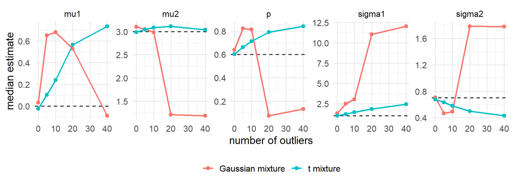

Figure 8

Already 5 outliers (1%) ruin the Gaussian mixture’s $\sigma_1$, and at 20 outliers one Gaussian component is used for the outliers alone. The $t$-mixture degrades gracefully — but with fixed $\nu$ it is not immune either.

# Summary

## What I learned

1. **Correctness**: a GEM step must *guarantee* an increase of $Q$ (v1 did not). Testing with `numDeriv`, Fisher’s identity and monotonicity caught the bugs — including a silent argument-name clash in `numDeriv`.
2. **Alternatives**: choosing more missing data ($W$) gives a closed-form EM, which is also a scaled gradient step on $Q$. Exact EM, gradient ascent and BFGS all reach the same point.
3. **Structure**: one generic driver + step-function factories + pluggable convergence criterion; an S3 class `tmix` on top.
4. **Benchmarking**: the same $\varepsilon$ does not mean the same accuracy — compare with a gradient criterion or against real time.
5. **Profiling**: the line search dominated the GEM (fixed by a warm start, 2× faster); `dt()`/`plogis()` dominated the EM. My own guess (`pow`) was wrong. Rcpp gave a modest gain and zero allocations.
6. **Theory matches practice**: three Fisher information methods agree, SEs match simulations, and the observed convergence rates equal $\rho(D\Phi)$.
7. **Robustness**: multiple local maxima (labelings), vanishing components for gradient-based methods, and the $t$-mixture is far more robust to outliers than the Gaussian mixture.